# Biological QA of the 6hr samples

Iryna Shutava, Thomas Dobrenel and Nicolas Delhomme

2019-08-30

# 1 Setup

Set the working dir

```r
setwd("/mnt/picea/projects/arabidopsis/jhanson/arabidopsis-nutrition-TOR")
```

Load libraries

```r
suppressPackageStartupMessages(library(DESeq2))
suppressPackageStartupMessages(library(gplots))
suppressPackageStartupMessages(library(limma))
suppressPackageStartupMessages(library(parallel))
suppressPackageStartupMessages(library(pander))
suppressPackageStartupMessages(library(RColorBrewer))
suppressPackageStartupMessages(library(tximport))
suppressPackageStartupMessages(library(vsn))
```

Source some helper functions

```r
source("~/Git/UPSCb/src/R/plot.multidensity.R")
source("~/Git/UPSCb/src/R/featureSelection.R")
```

Create palettes

```r
pal <- c(brewer.pal(8,"Dark2"),1)
cols <- rainbow(17)
hpal <- colorRampPalette(c("blue","white","red"))(100)
```

Register the default plot margin

```r
mar <- par("mar")
```

# 2 Raw data

## 2.1 Loading

Read the sample information

```r
samples <- read.csv("~/Git/UPSCb/projects/arabidopsis-nutrition-TOR/doc/samples2.csv")
```

Remove the samples of the 1st batch

```r
samples <- samples[! substr(samples$SciLifeID,1,8) == "P11554_1",]
```

Remove the samples of the 24hr timepoint

```r
samples <- samples[! samples$Timepoint == 24,]

# The data
filenames <- list.files("Salmon",
                    recursive = TRUE,
                    pattern = "quant.sf",
                    full.names = TRUE)
```

name them

```r
names(filenames) <- sub("_S.*","",sapply(strsplit(filenames, "/"), .subset, 2))
```

Reorder the sample data.frame according to the way the results were read in and accounting for tech reps

```r
samples <- samples[match(names(filenames),samples$SciLifeID),]
samples
```

```
##        SciLifeID SampleName Timepoint Nutrition  AZD
## NA          <NA>       <NA>        NA      <NA> <NA>
## NA.1        <NA>       <NA>        NA      <NA> <NA>
## NA.2        <NA>       <NA>        NA      <NA> <NA>
## NA.3        <NA>       <NA>        NA      <NA> <NA>
## NA.4        <NA>       <NA>        NA      <NA> <NA>
## NA.5        <NA>       <NA>        NA      <NA> <NA>
## NA.6        <NA>       <NA>        NA      <NA> <NA>
## NA.7        <NA>       <NA>        NA      <NA> <NA>
## NA.8        <NA>       <NA>        NA      <NA> <NA>
## NA.9        <NA>       <NA>        NA      <NA> <NA>
## NA.10       <NA>       <NA>        NA      <NA> <NA>
## NA.11       <NA>       <NA>        NA      <NA> <NA>
## NA.12       <NA>       <NA>        NA      <NA> <NA>
## NA.13       <NA>       <NA>        NA      <NA> <NA>
## NA.14       <NA>       <NA>        NA      <NA> <NA>
## NA.15       <NA>       <NA>        NA      <NA> <NA>
## NA.16       <NA>       <NA>        NA      <NA> <NA>
## NA.17       <NA>       <NA>        NA      <NA> <NA>
## 2     P11554_202       J0-7         0        T0    0
## 3     P11554_203      J0-23         0        T0    0
## 4     P11554_204       J0-5         0        T0    0
## 5     P11554_205      J0-21         0        T0    0
## 6     P11554_206      J0-11         0        T0    0
## 7     P11554_207       I6-1         6       NPS DMSO
## 8     P11554_208       I6-2         6       NPS DMSO
## 9     P11554_209       I6-3         6       NPS DMSO
## 10    P11554_210       J6-4         6       NPS  AZD
## 11    P11554_211       I6-5         6       NPS  AZD
## 12    P11554_212       I6-6         6       NPS  AZD
## 13    P11554_213       I6-7         6        NP DMSO
## 14    P11554_214       I6-8         6        NP DMSO
## 15    P11554_215       I6-9         6        NP DMSO
## 16    P11554_216      I6-10         6        NP  AZD
## 17    P11554_217      I6-11         6        NP  AZD
## 18    P11554_218      I6-12         6        NP  AZD
## 19    P11554_219      I6-13         6       PKS DMSO
## 20    P11554_220      I6-14         6       PKS DMSO
## 21    P11554_221      I6-15         6       PKS DMSO
## 22    P11554_222      I6-16         6       PKS  AZD
## 23    P11554_223      I6-17         6       PKS  AZD
## 24    P11554_224      I6-18         6       PKS  AZD
## 25    P11554_225      I6-19         6        NS DMSO
## 26    P11554_226      I6-20         6        NS DMSO
## 27    P11554_227      I6-21         6        NS DMSO
## 28    P11554_228      I6-22         6        NS  AZD
## 29    P11554_229      I6-23         6        NS  AZD
## 30    P11554_230      I6-24         6        NS  AZD
## NA.18       <NA>       <NA>        NA      <NA> <NA>
## NA.19       <NA>       <NA>        NA      <NA> <NA>
## NA.20       <NA>       <NA>        NA      <NA> <NA>
## NA.21       <NA>       <NA>        NA      <NA> <NA>
## NA.22       <NA>       <NA>        NA      <NA> <NA>
## NA.23       <NA>       <NA>        NA      <NA> <NA>
## NA.24       <NA>       <NA>        NA      <NA> <NA>
## 119   P13406_101       J0-7         0        T0    0
## NA.25       <NA>       <NA>        NA      <NA> <NA>
## NA.26       <NA>       <NA>        NA      <NA> <NA>
## NA.27       <NA>       <NA>        NA      <NA> <NA>
## NA.28       <NA>       <NA>        NA      <NA> <NA>
## 124   P13406_106      I0-18         0        T0    0
```

Remove the NAs

```r
samples <- na.omit(samples)
```

Rename rows

```r
rownames(samples) <- samples$SciLifeID

samples$Conditions <- factor(paste(samples$Timepoint,samples$Nutrition,samples$AZD,sep="_"))
samples$Batch <- factor(substr(samples$SciLifeID,1,8))
```

Clean-up the sample list in the filenames

```r
filenames <- filenames[match(samples$SciLifeID,names(filenames))]
```

Read the expression at the transcript level

```r
tx <- suppressMessages(tximport(files = filenames,
                                type = "salmon",
                                txOut = TRUE))
```

summarise to genes

```r
tx2gene <- data.frame(TXID=rownames(tx$counts),
                      GENEID=sub("\\.[0-9]+","",rownames(tx$counts)))

gx <- summarizeToGene(tx,tx2gene=tx2gene)
```

```
## summarizing abundance
```

```
## summarizing counts
```

```
## summarizing length
```

```r
kg <- round(gx$counts)
```

Sanity check

```r
stopifnot(all(colnames(kg) == samples$SciLifeID))
```

## 2.2 Raw data export

```r
#dir.create(file.path("analysis_Tom","salmon"),showWarnings=FALSE,recursive=TRUE)
#write.table(kg,file="/mnt/picea/projects/arabidopsis/jhanson/arabidopsis-nutrition-TOR/analysis_Tom/nutrition-unormalised-gene-expression_data.csv")
#save(kg, samples, file = "/mnt/picea/projects/arabidopsis/jhanson/arabidopsis-nutrition-TOR/analysis_Tom/counts.rda")
```

## 2.3 Preliminary validations

### 2.3.1 Check for the genes that are never expressed

```r
sel <- rowSums(kg) == 0
sprintf("%s%% (%s) of %s genes are not expressed",
        round(sum(sel) * 100/ nrow(kg),digits=1),
        sum(sel),
        nrow(kg))
```

```
## [1] "19.2% (6216) of 32310 genes are not expressed"
```

### 2.3.2 Display the samples mean raw counts distribution

i.e. the mean raw count of every gene across samples is calculated and displayed on a log10 scale.

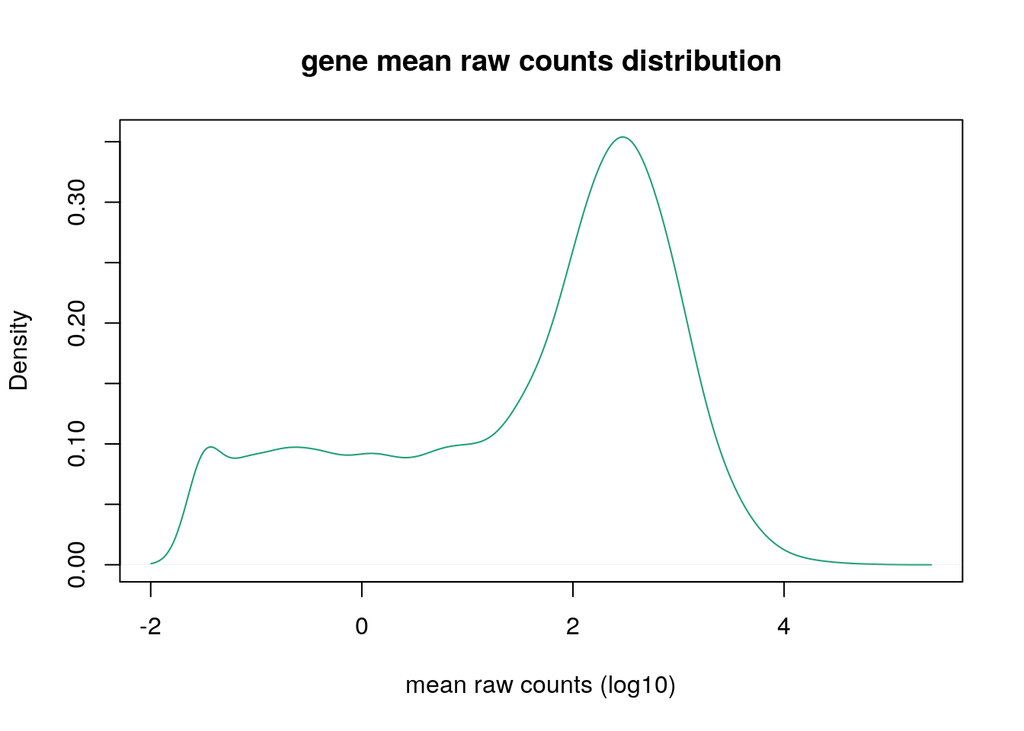

```r
plot(density(log10(rowMeans(kg))),col=pal[1],
     main="gene mean raw counts distribution",
     xlab="mean raw counts (log10)")
```

### 2.3.3 Display all samples raw counts distribution

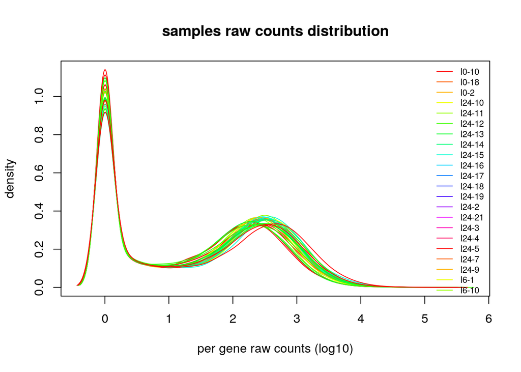

```r
plot.multidensity(log10(kg+1),
                  col=cols[as.integer(samples$Conditions)],
                  legend.x="topright",
                  legend=levels(samples$SampleName),
                  legend.col=cols,
                  legend.lwd=1,legend.cex=.7,
                  main="samples raw counts distribution",
                  xlab="per gene raw counts (log10)")
```

# 3 Data normalisation

For visualization, the data is submitted to a variance stabilization transformation using DESeq2. The dispersion is estimated independently of the sample type

```r
dds <- DESeqDataSetFromMatrix(
    countData = kg,
    colData = samples,
    design = ~ Conditions)
```

Check the size factors (i.e. the sequencing library size effect) There is no big variation, a Variance Stabilizing Transformation can be used (over a Relative Log Transformation)

```r
dds <- estimateSizeFactors(dds)
sizes <- sizeFactors(dds)
names(sizes) <- colnames(kg)
sizes
```

```
## P11554_202 P11554_203 P11554_204 P11554_205 P11554_206 P11554_207
##  0.6288200  0.8182236  0.6620370  0.8213572  0.9081838  1.1677705
## P11554_208 P11554_209 P11554_210 P11554_211 P11554_212 P11554_213
##  0.9773663  0.8148135  0.9047056  1.3350351  1.0710435  0.9097133
## P11554_214 P11554_215 P11554_216 P11554_217 P11554_218 P11554_219
##  1.0852405  1.0315593  1.0436155  1.1045521  1.1999608  1.3772748
## P11554_220 P11554_221 P11554_222 P11554_223 P11554_224 P11554_225
##  1.0529589  1.1635106  1.3009925  1.0207299  1.0974615  0.6841548
## P11554_226 P11554_227 P11554_228 P11554_229 P11554_230 P13406_101
##  1.0168201  1.0539226  1.2315953  0.7074239  0.8601718  1.5143916
## P13406_106
##  1.1322230
```

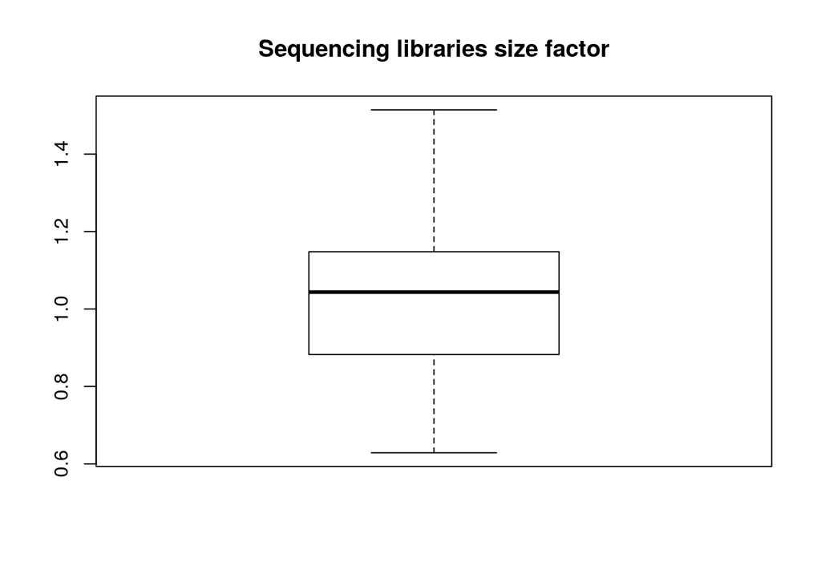

```r
boxplot(sizes, main="Sequencing libraries size factor")
```

split by batch effect

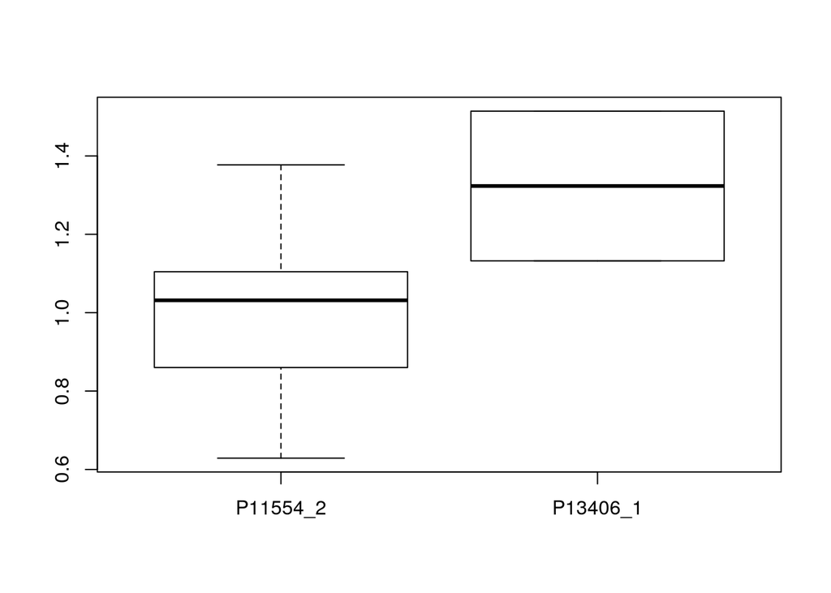

```r
boxplot(split(sizes,samples$Batch))
```

## 3.1 VST

```r
vsd <- varianceStabilizingTransformation(dds, blind=TRUE)
vst <- assay(vsd)
vst <- vst - min(vst)
```

Validation

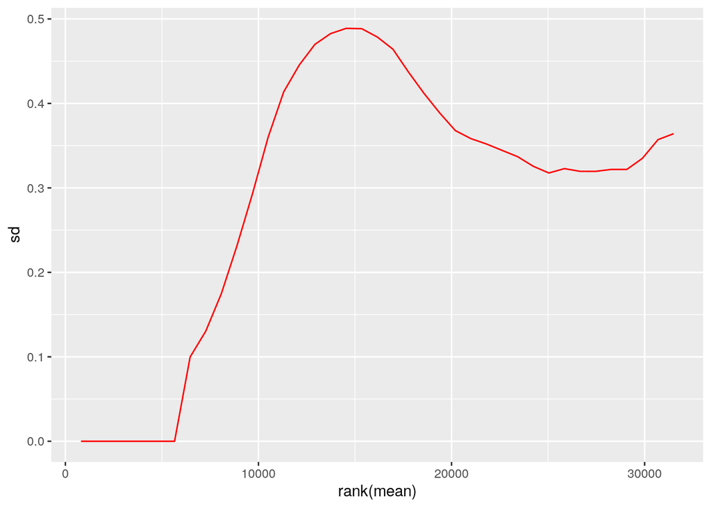

```r
meanSdPlot(vst)
```

Write out

```r
#write.csv(vst,"/mnt/picea/projects/arabidopsis/jhanson/arabidopsis-nutrition-TOR/analysis_Tom/library-size-normalized_variance-stabilized_data_nutrition.csv")
```

## 3.2 Biological QA

### 3.2.1 MDS

Verification of the sample distribution by a multivariate approach on the raw data

- Samples

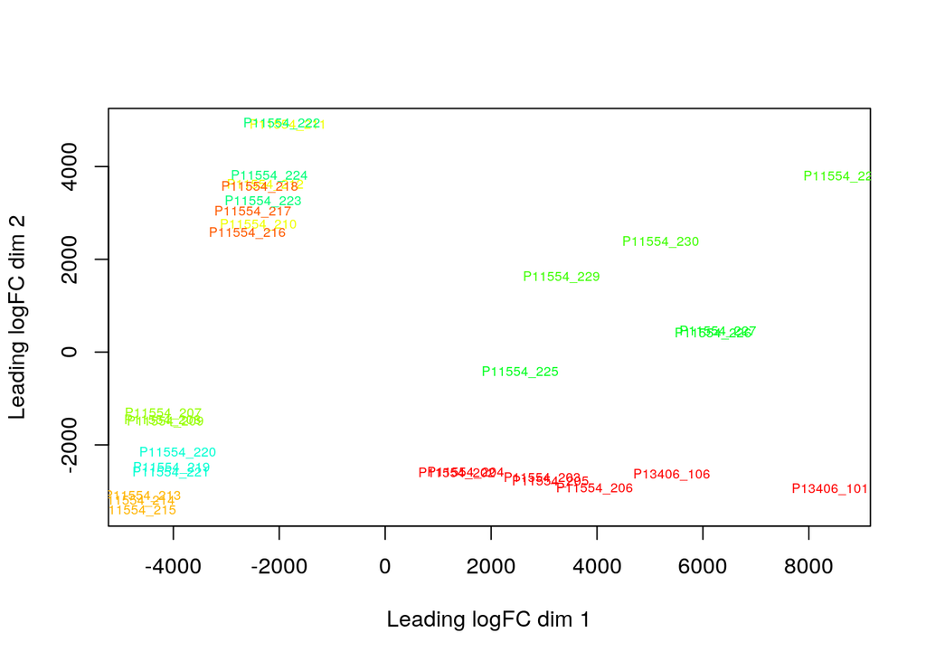

```r
plotMDS(kg,cex=.6,col=cols[as.integer(samples$Conditions)])
```

### 3.2.2 PCA

Principal Component Analysis on the normalized data

- Colour coded by Nutrition and AZD treatment - all data

```r
conditions1 <- factor(paste(samples$AZD,samples$Nutrition,sep="_"))
pch<-as.integer(factor(samples$Timepoint))+14
pc <- prcomp(t(vst))
percent <- round(summary(pc)$importance[2,]*100);percent
```

```
##  PC1  PC2  PC3  PC4  PC5  PC6  PC7  PC8  PC9 PC10 PC11 PC12 PC13 PC14 PC15
##   37   31   11    2    2    1    1    1    1    1    1    1    1    1    1
## PC16 PC17 PC18 PC19 PC20 PC21 PC22 PC23 PC24 PC25 PC26 PC27 PC28 PC29 PC30
##    1    1    1    1    1    1    1    1    1    1    1    0    0    0    0
## PC31
##    0
```

- Drawing the PCA

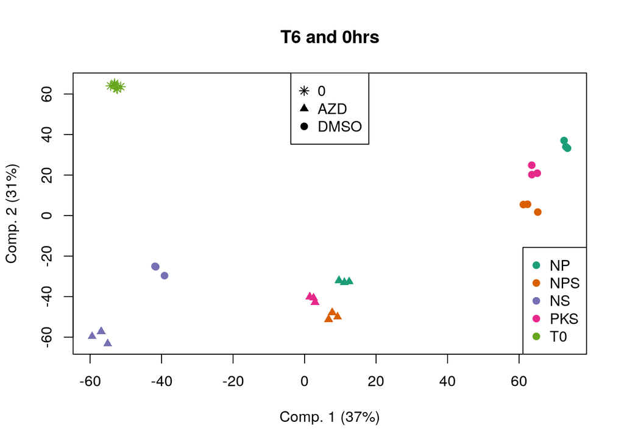

```r
t.sel <- samples$Timepoint %in% c(0,24)
conds <- droplevels(conditions1[t.sel])
plot(pc$x[,1],
     pc$x[,2],
     xlab=paste("Comp. 1 (",percent[1],"%)",sep=""),
     ylab=paste("Comp. 2 (",percent[2],"%)",sep=""),
     col=pal[as.integer(samples$Nutrition)],
     pch=c(8,17,19)[as.integer(samples$AZD)],
     main="T6 and 0hrs")

legend("bottomright",pch=19,
       col=pal[1:nlevels(samples$Nutrition)],
       legend=levels(samples$Nutrition))

legend("top",pch=c(8,17,19),
       col="black",
       legend=levels(samples$AZD))
```

# 4 Heatmaps

## 4.1 All nutritions

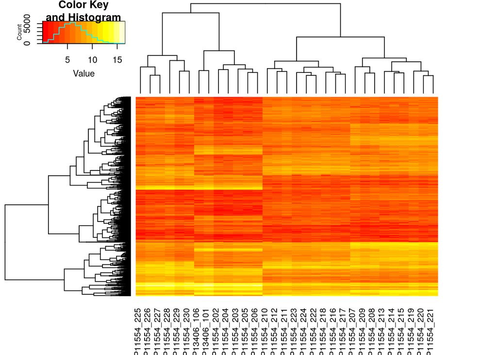

```r
counts <- tx$counts
sel <- order(apply(log2(counts),1,sd),decreasing=TRUE)[1:1000]
heatmap.2(log2(counts[sel,]+1),labRow = NA,trace = "none")
```

## 4.2 Only +/- phosphorus with T0

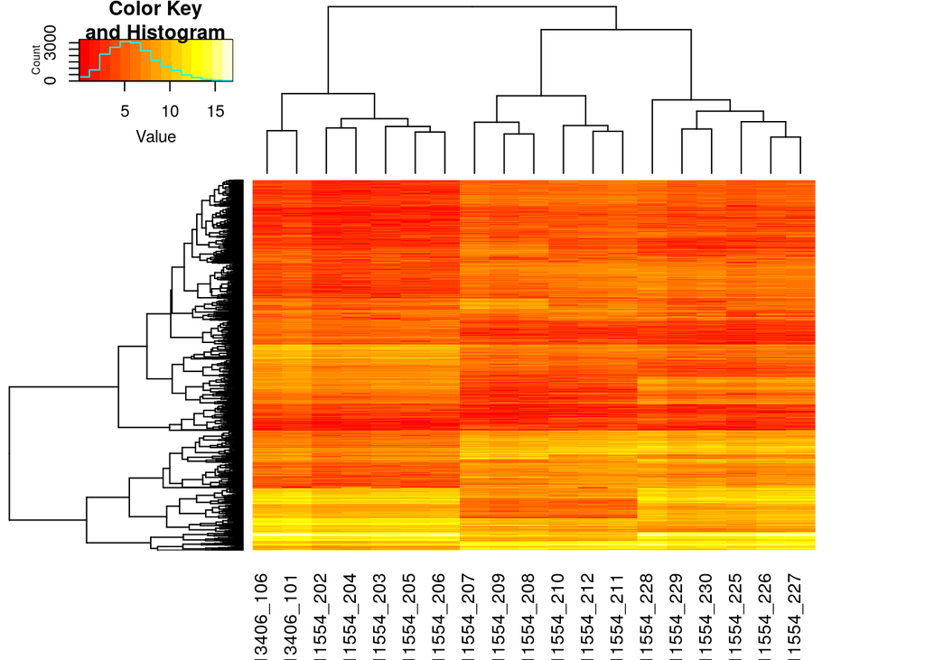

```r
ssel <- samples$SciLifeID[samples$Timepoint %in% c(0,6) &
                              samples$Nutrition %in% c("NPS","NS","T0") &
                              substr(colnames(tx$counts),1,8) %in% c("P11554_2","P13406_1")]
counts <- tx$counts[,substr(colnames(tx$counts),1,8) %in% c("P11554_2","P13406_1")]
counts <- tx$counts[,colnames(tx$counts) %in% factor(ssel)]
sel <- order(apply(log2(counts),1,sd),decreasing=TRUE)[1:1000]
heatmap.2(log2(counts[sel,]+1),labRow = NA,trace = "none")
hm <- heatmap.2(log2(counts[sel,]+1),labRow = NA,trace = "none")
```

## 4.3 Only +/- phosphorus without T0

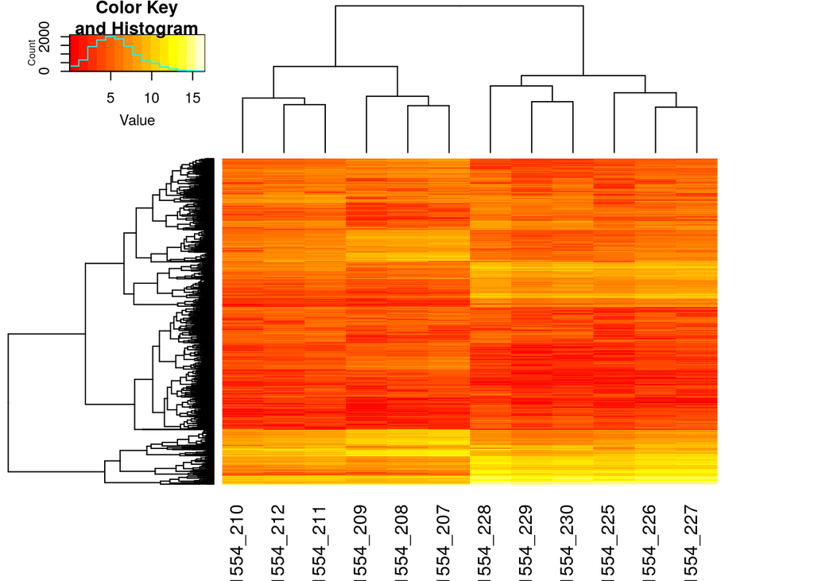

```r
ssel <- samples$SciLifeID[samples$Timepoint %in% c(0,6) &
                              samples$Nutrition %in% c("NPS","NS") &
                              substr(colnames(tx$counts),1,8) %in% c("P11554_2","P13406_1")]
counts <- tx$counts[,substr(colnames(tx$counts),1,8) %in% c("P11554_2","P13406_1")]
counts <- tx$counts[,colnames(tx$counts) %in% factor(ssel)]
sel <- order(apply(log2(counts),1,sd),decreasing=TRUE)[1:1000]
heatmap.2(log2(counts[sel,]+1),labRow = NA,trace = "none")
```

```r
#norm_data <- read.csv("Tom-normalizedToT0-data-vst-blind.csv",row.names = 1)
#ssel <- samples$SciLifeID[samples$Timepoint %in% c(0,6) &
#                              samples$Nutrition %in% c("NPS","NS","T0") &
#                              substr(colnames(tx$counts),1,8) %in% c("P11554_2","P13406_1")]
#counts <- norm_data[,colnames(norm_data) %in% factor(ssel)]
#sel <- order(apply(log2(counts),1,sd),decreasing=TRUE)[1:1000]
#heatmap.2(log2(counts[sel,]+1),labRow = NA,trace = "none")

#ssel <- samples$SciLifeID[samples$Timepoint %in% c(0,6) &
#                              samples$Nutrition %in% c("NPS","NS") &
#                              substr(colnames(tx$counts),1,8) %in% c("P11554_2","P13406_1")]
#counts <- tx$counts[,substr(colnames(tx$counts),1,8) %in% c("P11554_2","P13406_1")]
#counts <- tx$counts[,colnames(tx$counts) %in% factor(ssel)]
#sel <- order(apply(log2(counts),1,sd),decreasing=TRUE)[1:1000]
#heatmap.2(log2(counts[sel,]+1),labRow = NA,trace = "none")
```